# Stacking

# 6. Models for stacking

In this section, we will define several model workflows and use `tune_grid()` for hyperparameter tuning. Unlike ordinary tuning where the best models will be selected, our approach differs.

We will attempt to tune only for the purpose of generating multiple variations of the same model with different hyperparameters. These different models will then be added to a stack, allowing the stacking algorithm to select the models that are the most important and allowing it to give a weighted-average or meta-model ensemble that would be more robust than a tuned model that stands on its own.

## 6.1 Convenience functions

To start on the model workflows, we first create some convenience functions that are related to stacking so that they can be used in our modelling workflow.

These functions are similar to `control_grid()` and `control_resamples()` under the normal circumstances where there is no stacking. `control_stack_grid()` is used when there is hyperparameter tuning, while `control_stack_resamples()` is used when there is no tuning.

```r
# Convenience functions. Set save_pred = TRUE, save_workflow = TRUE
# To be used in tune_grid(control = ) later for each model
ctrl_grid <- control_stack_grid()
ctrl_res <- control_stack_resamples()
```

## 6.2 XGBoost model

```r
xgb_model <- boost_tree(learn_rate = 0.01,
                        tree_depth = tune(),
                        min_n = 1,
                        mtry = 500,
                        trees = tune(),
                        stop_iter = 50) %>%
  set_engine('xgboost') %>%
  set_mode('classification')

# Workflow for the entire model
xgb_wflw <- workflow() %>%
  add_recipe(recipe_spec) %>%
  add_model(xgb_model)

# creating a grid to tune trees
# number of models =5^3 = 125
xgb_params <- grid_regular(trees(),
                           tree_depth(),
                           levels = 5)

# Fit models at all different values chosen for each hyperparameter
# 7 Folds. Results reported for each row.
xgb_model_results <- xgb_wflw %>% tune_grid(
  grid = xgb_params,
  metrics = metric_set(accuracy, roc_auc, mn_log_loss),  # Mean log loss
  resamples = resamples_cv,
  control = ctrl_grid)


# Display results in a tidy tibble
# Each model would be ran using the cross-fold validation. Average performance statstics reported back.
# Note that the cross-fold validation models are not kept. Only using cross-fold validation to calculate performance statistics for us to choose which model parameters to use.
# no. of models x no. of metrics
xgb_model_results %>%
  collect_metrics()
```

```
# # A tibble: 75 x 8
#    trees tree_depth .metric    .estimator  mean     n  std_err .config
#    <int>      <int> <chr>      <chr>      <dbl> <int>    <dbl> <fct>
#  1     1          1 accuracy   binary     0.497    11 0.0175   Preprocessor1_Mo~
#  2     1          1 mn_log_lo~ binary     0.693    11 0.000118 Preprocessor1_Mo~
#  3     1          1 roc_auc    binary     0.501    11 0.00869  Preprocessor1_Mo~
#  4   500          1 accuracy   binary     0.496    11 0.0246   Preprocessor1_Mo~
#  5   500          1 mn_log_lo~ binary     0.697    11 0.00539  Preprocessor1_Mo~
#  6   500          1 roc_auc    binary     0.540    11 0.0160   Preprocessor1_Mo~
#  7  1000          1 accuracy   binary     0.495    11 0.0248   Preprocessor1_Mo~
#  8  1000          1 mn_log_lo~ binary     0.699    11 0.00577  Preprocessor1_Mo~
#  9  1000          1 roc_auc    binary     0.538    11 0.0159   Preprocessor1_Mo~
# 10  1500          1 accuracy   binary     0.495    11 0.0248   Preprocessor1_Mo~
# # ... with 65 more rows
```

## 6.3 Support Vector Machine

```r
# creating model specifications
svm_spec <- svm_rbf(
    cost=tune(),
    rbf_sigma=tune()
  ) %>%
  set_engine("kernlab") %>%
  set_mode("classification")

# Creating a parameter grid
# grid_regular chooses sensible values for cost and rbg_sigma
# number of total models = 5*5 = 25
svm_grid <- grid_regular(cost(),
                         rbf_sigma(),
                         levels=5)

# Creating workflow
svm_wflow <- workflow() %>%
  add_model(svm_spec) %>%
  add_recipe(recipe_spec)

# Results of the model. These results will be added to the stack.
svm_results <- svm_wflow %>%
  tune_grid(
    resamples=resamples_cv,
    grid=svm_grid,
    control=ctrl_grid
  )

svm_results %>%
  collect_metrics()
```

```
# # A tibble: 50 x 8
#         cost   rbf_sigma .metric .estimator  mean     n std_err .config
#        <dbl>       <dbl> <chr>   <chr>      <dbl> <int>   <dbl> <fct>
#  1  0.000977    1.00e-10 accura~ binary     0.501    11  0.0282 Preprocessor1_M~
#  2  0.000977    1.00e-10 roc_auc binary     0.535    11  0.0233 Preprocessor1_M~
#  3  0.0131      1.00e-10 accura~ binary     0.501    11  0.0282 Preprocessor1_M~
#  4  0.0131      1.00e-10 roc_auc binary     0.535    11  0.0231 Preprocessor1_M~
#  5  0.177       1.00e-10 accura~ binary     0.501    11  0.0282 Preprocessor1_M~
#  6  0.177       1.00e-10 roc_auc binary     0.535    11  0.0231 Preprocessor1_M~
#  7  2.38        1.00e-10 accura~ binary     0.501    11  0.0282 Preprocessor1_M~
#  8  2.38        1.00e-10 roc_auc binary     0.516    11  0.0251 Preprocessor1_M~
#  9 32           1.00e-10 accura~ binary     0.501    11  0.0282 Preprocessor1_M~
# 10 32           1.00e-10 roc_auc binary     0.542    11  0.0219 Preprocessor1_M~
# # ... with 40 more rows
```

## 6.4 Random Forest

Usually low maintenance and performs well. Here we use ranger and random forest engines to see how a random forest model would perform.

### 6.4.1 Ranger

```r
rf_ranger_spec <- rand_forest(trees = tune(),
                              min_n=tune()

  ) %>%
  set_engine("ranger") %>%
  set_mode("classification")

# Creating a parameter grid
# grid_regular chooses sensible values for trees and min)n
# number of total models = 5^3 = 125
rf_ranger_grid <- grid_regular(trees(),
                               min_n(),
                               levels=5)

# Creating workflow
rf_ranger_wflow <- workflow() %>%
  add_model(rf_ranger_spec) %>%
  add_recipe(recipe_spec)

# Results of the model
rf_ranger_results <- rf_ranger_wflow %>%
  tune_grid(
    resamples=resamples_cv,
    grid=rf_ranger_grid,
    control=ctrl_grid
  )

rf_ranger_results %>%
  collect_metrics()
```

```
# # A tibble: 50 x 8
#    trees min_n .metric  .estimator  mean     n std_err .config
#    <int> <int> <chr>    <chr>      <dbl> <int>   <dbl> <fct>
#  1     1     2 accuracy binary     0.503    11 0.0238  Preprocessor1_Model01
#  2     1     2 roc_auc  binary     0.515    11 0.0216  Preprocessor1_Model01
#  3   500     2 accuracy binary     0.510    11 0.0163  Preprocessor1_Model02
#  4   500     2 roc_auc  binary     0.575    11 0.0116  Preprocessor1_Model02
#  5  1000     2 accuracy binary     0.532    11 0.0208  Preprocessor1_Model03
#  6  1000     2 roc_auc  binary     0.578    11 0.0107  Preprocessor1_Model03
#  7  1500     2 accuracy binary     0.519    11 0.0213  Preprocessor1_Model04
#  8  1500     2 roc_auc  binary     0.581    11 0.0100  Preprocessor1_Model04
#  9  2000     2 accuracy binary     0.524    11 0.0207  Preprocessor1_Model05
# 10  2000     2 roc_auc  binary     0.580    11 0.00988 Preprocessor1_Model05
# # ... with 40 more rows
```

### 6.4.2 randomForest

```r
rf_randomForest_spec <- rand_forest(trees = tune(),
                                    min_n=tune()

  ) %>%
  set_engine("randomForest") %>%
  set_mode("classification")

# Creating a parameter grid
# grid_regular chooses sensible values for trees and min)n
# number of total models = 5^3 = 125
rf_randomForest_grid <- grid_regular(trees(),
                                     min_n(),
                                     levels=5)

# Creating workflow
rf_randomForest_wflow <- workflow() %>%
  add_model(rf_randomForest_spec) %>%
  add_recipe(recipe_spec)

# Results of the model
rf_randomForest_results <- rf_randomForest_wflow %>%
  tune_grid(
    resamples=resamples_cv,
    grid=rf_randomForest_grid,
    control = ctrl_grid
  )

rf_randomForest_results %>%
  collect_metrics()
```

```
# # A tibble: 50 x 8
#    trees min_n .metric  .estimator  mean     n std_err .config
#    <int> <int> <chr>    <chr>      <dbl> <int>   <dbl> <fct>
#  1     1     2 accuracy binary     0.517    11 0.0123  Preprocessor1_Model01
#  2     1     2 roc_auc  binary     0.536    11 0.0134  Preprocessor1_Model01
#  3   500     2 accuracy binary     0.515    11 0.0185  Preprocessor1_Model02
#  4   500     2 roc_auc  binary     0.571    11 0.00961 Preprocessor1_Model02
#  5  1000     2 accuracy binary     0.507    11 0.0223  Preprocessor1_Model03
#  6  1000     2 roc_auc  binary     0.572    11 0.00924 Preprocessor1_Model03
#  7  1500     2 accuracy binary     0.506    11 0.0190  Preprocessor1_Model04
#  8  1500     2 roc_auc  binary     0.576    11 0.0102  Preprocessor1_Model04
#  9  2000     2 accuracy binary     0.514    11 0.0230  Preprocessor1_Model05
# 10  2000     2 roc_auc  binary     0.578    11 0.0102  Preprocessor1_Model05
# # ... with 40 more rows
```

## 6.4 Null model

A [null model](https://smltar.com/mlclassification.html#classfirstattemptlookatdata) or a baseline model is a simple, non-informative model that always predicts the largest class for classification. Such a model is perhaps the simplest heuristics or rull-based alternative that we can consider as we assess our modelling efforts. Even though the null model might not be the most useful, let’s just have it go through stacking to see if it is able to provide any additional information.

```r
null_classification <- null_model() %>%
  set_engine("parsnip") %>%
  set_mode("classification")

# note that control_resamples() was used here as there was no hyperparameter tuning.
null_results <- workflow() %>%
  add_recipe(recipe_spec) %>%
  add_model(null_classification) %>%
  fit_resamples(
    resamples_cv,
    control=control_stack_resamples()
  )


# results of a null model
null_results %>% collect_metrics()
```

```
# # A tibble: 2 x 6
#   .metric  .estimator  mean     n std_err .config
#   <chr>    <chr>      <dbl> <int>   <dbl> <fct>
# 1 accuracy binary     0.508    11  0.0280 Preprocessor1_Model1
# 2 roc_auc  binary     0.5      11  0      Preprocessor1_Model1
```

## 6.4 Neural Networks

```r
nnet_spec <- mlp(penalty = tune(),
                 epochs = tune()) %>%
  set_mode("classification") %>%
  set_engine("nnet")

# Define Workflow
nnet_wflow <- workflow() %>%
  add_recipe(recipe_spec) %>%
  add_model(nnet_spec)

# Grid for tuning
# 5^2 = 25number of nn models
nnet_grid <- grid_regular(penalty(),
                          epochs(),
                          levels=5)

# Perform tuning and cross-validation on training set
nnet_results <- nnet_wflow %>%
  tune_grid(
    resamples = resamples_cv,
    grid = nnet_grid,
    metrics = metric_set(accuracy, roc_auc, mn_log_loss),
    control = ctrl_grid
  )

nnet_results %>% collect_metrics
```

```
# # A tibble: 75 x 8
#        penalty epochs .metric    .estimator  mean     n std_err .config
#          <dbl>  <int> <chr>      <chr>      <dbl> <int>   <dbl> <fct>
#  1    1.00e-10     10 accuracy   binary     0.508    11 2.80e-2 Preprocessor1_M~
#  2    1.00e-10     10 mn_log_lo~ binary     0.693    11 1.02e-3 Preprocessor1_M~
#  3    1.00e-10     10 roc_auc    binary     0.507    11 4.98e-3 Preprocessor1_M~
#  4    3.16e- 8     10 accuracy   binary     0.501    11 2.82e-2 Preprocessor1_M~
#  5    3.16e- 8     10 mn_log_lo~ binary     0.693    11 9.71e-4 Preprocessor1_M~
#  6    3.16e- 8     10 roc_auc    binary     0.5      11 0.      Preprocessor1_M~
#  7    1.00e- 5     10 accuracy   binary     0.508    11 2.80e-2 Preprocessor1_M~
#  8    1.00e- 5     10 mn_log_lo~ binary     0.694    11 1.05e-3 Preprocessor1_M~
#  9    1.00e- 5     10 roc_auc    binary     0.497    11 2.57e-3 Preprocessor1_M~
# 10    3.16e- 3     10 accuracy   binary     0.508    11 2.80e-2 Preprocessor1_M~
# # ... with 65 more rows
```

## 6.5 Logistic Regression

```r
logistic_spec <- logistic_reg(penalty=tune(),
                              mixture=tune()) %>%
  set_engine("glm") %>%
  set_mode("classification")

# Creating a parameter grid
# grid_regular chooses sensible values for trees and min)n
# number of total models = 5^3 = 125
logistic_grid <- grid_regular(penalty(),
                              mixture(),
                              levels=5)

# Creating workflow
logistic_wflow <- workflow() %>%
  add_model(logistic_spec) %>%
  add_recipe(recipe_spec)

# Results of the model
logistic_results <- logistic_wflow %>%
  tune_grid(
    resamples = resamples_cv,
    grid = logistic_grid,
    metrics = metric_set(accuracy, roc_auc),
    control = ctrl_grid
  )



logistic_results %>% collect_metrics
```

```
# # A tibble: 2 x 6
#   .metric  .estimator  mean     n std_err .config
#   <chr>    <chr>      <dbl> <int>   <dbl> <fct>
# 1 accuracy binary     0.489    11  0.0251 Preprocessor1_Model1
# 2 roc_auc  binary     0.539    11  0.0133 Preprocessor1_Model1
```

## 6.6 Other Classification models

Other classification models available in parsnips include: decision_tree bag_tree nearest_neighbour

# 7. stacking

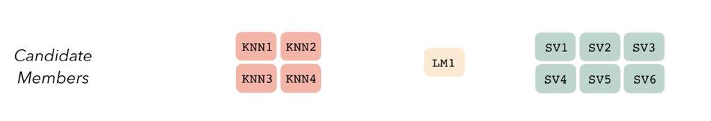

Stacking is when we add different models together into a `data_stack` object through the `add_candidates()` function.

The end result is simply a tibble of different models and their predictions together with the actual y-variable we are trying to predict.

```r
# initialising the stacks
stacks()
```

```
# # A data stack with 0 model definitions and 0 candidate members.
```

```r
# add_candidates() adds ensemble members to the stack
stacked_model <- stacks() %>%
  add_candidates(xgb_model_results) %>%
  add_candidates(svm_results) %>%
  add_candidates(rf_ranger_results) %>%
  add_candidates(rf_randomForest_results) %>%
  add_candidates(null_results) %>%
  add_candidates(nnet_results) %>%
  add_candidates(logistic_results)

stacked_model
```

```
# # A data stack with 7 model definitions and 120 candidate members:
# #   xgb_model_results: 18 model configurations
# #   svm_results: 25 model configurations
# #   rf_ranger_results: 25 model configurations
# #   rf_randomForest_results: 25 model configurations
# #   null_results: 1 model configuration
# #   nnet_results: 25 model configurations
# #   logistic_results: 1 model configuration
# # Outcome: future_return_sign (factor)
```

Showing the results of the different models in the data_stack object. The first column contains actual future_return_sign (our target variable). Every other column contains the predicted values for each of the models that we have added into the stack.

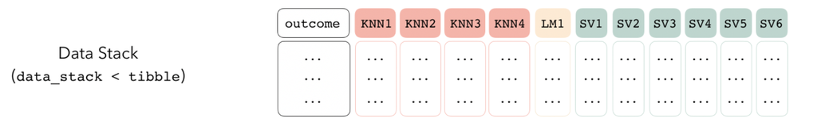

```r
as_tibble(stacked_model)
```

```
# # A tibble: 891 x 241
#    future_return_s~ .pred_0_xgb_mod~ .pred_0_xgb_mod~ .pred_0_xgb_mod~
#    <fct>                       <dbl>            <dbl>            <dbl>
#  1 0                           0.501            0.502            0.502
#  2 1                           0.501            0.502            0.502
#  3 1                           0.501            0.498            0.497
#  4 1                           0.501            0.498            0.497
#  5 0                           0.499            0.503            0.503
#  6 0                           0.499            0.503            0.503
#  7 1                           0.499            0.496            0.496
#  8 0                           0.501            0.502            0.502
#  9 1                           0.501            0.502            0.502
# 10 0                           0.499            0.503            0.503
# # ... with 881 more rows, and 237 more variables:
# #   .pred_0_xgb_model_results_1_16 <dbl>, .pred_0_xgb_model_results_1_21 <dbl>,
# #   .pred_0_xgb_model_results_1_02 <dbl>, .pred_0_xgb_model_results_1_07 <dbl>,
# #   .pred_0_xgb_model_results_1_12 <dbl>, .pred_0_xgb_model_results_1_17 <dbl>,
# #   .pred_0_xgb_model_results_1_22 <dbl>, .pred_0_xgb_model_results_1_03 <dbl>,
# #   .pred_0_xgb_model_results_1_08 <dbl>, .pred_0_xgb_model_results_1_09 <dbl>,
# #   .pred_0_xgb_model_results_1_05 <dbl>, .pred_0_xgb_model_results_1_10 <dbl>,
# #   .pred_0_xgb_model_results_1_15 <dbl>, .pred_0_xgb_model_results_1_20 <dbl>,
# #   .pred_0_xgb_model_results_1_25 <dbl>, .pred_1_xgb_model_results_1_01 <dbl>,
# #   .pred_1_xgb_model_results_1_06 <dbl>, .pred_1_xgb_model_results_1_11 <dbl>,
# #   .pred_1_xgb_model_results_1_16 <dbl>, .pred_1_xgb_model_results_1_21 <dbl>,
# #   .pred_1_xgb_model_results_1_02 <dbl>, .pred_1_xgb_model_results_1_07 <dbl>,
# #   .pred_1_xgb_model_results_1_12 <dbl>, .pred_1_xgb_model_results_1_17 <dbl>,
# #   .pred_1_xgb_model_results_1_22 <dbl>, .pred_1_xgb_model_results_1_03 <dbl>,
# #   .pred_1_xgb_model_results_1_08 <dbl>, .pred_1_xgb_model_results_1_09 <dbl>,
# #   .pred_1_xgb_model_results_1_05 <dbl>, .pred_1_xgb_model_results_1_10 <dbl>,
# #   .pred_1_xgb_model_results_1_15 <dbl>, .pred_1_xgb_model_results_1_20 <dbl>,
# #   .pred_1_xgb_model_results_1_25 <dbl>, .pred_0_svm_results_1_01 <dbl>,
# #   .pred_0_svm_results_1_06 <dbl>, .pred_0_svm_results_1_11 <dbl>,
# #   .pred_0_svm_results_1_16 <dbl>, .pred_0_svm_results_1_21 <dbl>,
# #   .pred_0_svm_results_1_02 <dbl>, .pred_0_svm_results_1_07 <dbl>,
# #   .pred_0_svm_results_1_12 <dbl>, .pred_0_svm_results_1_17 <dbl>,
# #   .pred_0_svm_results_1_22 <dbl>, .pred_0_svm_results_1_03 <dbl>,
# #   .pred_0_svm_results_1_08 <dbl>, .pred_0_svm_results_1_13 <dbl>,
# #   .pred_0_svm_results_1_18 <dbl>, .pred_0_svm_results_1_23 <dbl>,
# #   .pred_0_svm_results_1_04 <dbl>, .pred_0_svm_results_1_09 <dbl>,
# #   .pred_0_svm_results_1_14 <dbl>, .pred_0_svm_results_1_19 <dbl>,
```

[output cut: 10 more lines]

```
# #   .pred_1_svm_results_1_23 <dbl>, .pred_1_svm_results_1_04 <dbl>,
# #   .pred_1_svm_results_1_09 <dbl>, .pred_1_svm_results_1_14 <dbl>,
# #   .pred_1_svm_results_1_19 <dbl>, .pred_1_svm_results_1_24 <dbl>,
# #   .pred_1_svm_results_1_05 <dbl>, .pred_1_svm_results_1_10 <dbl>,
# #   .pred_1_svm_results_1_15 <dbl>, .pred_1_svm_results_1_20 <dbl>,
# #   .pred_1_svm_results_1_25 <dbl>, .pred_0_rf_ranger_results_1_01 <dbl>,
# #   .pred_0_rf_ranger_results_1_06 <dbl>, .pred_0_rf_ranger_results_1_11 <dbl>,
# #   .pred_0_rf_ranger_results_1_16 <dbl>, .pred_0_rf_ranger_results_1_21 <dbl>,
# #   .pred_0_rf_ranger_results_1_02 <dbl>, .pred_0_rf_ranger_results_1_07 <dbl>,
# #   .pred_0_rf_ranger_results_1_12 <dbl>, .pred_0_rf_ranger_results_1_17 <dbl>,
# #   .pred_0_rf_ranger_results_1_22 <dbl>, .pred_0_rf_ranger_results_1_03 <dbl>,
# #   .pred_0_rf_ranger_results_1_08 <dbl>, .pred_0_rf_ranger_results_1_13 <dbl>,
# #   .pred_0_rf_ranger_results_1_18 <dbl>, .pred_0_rf_ranger_results_1_23 <dbl>,
# #   .pred_0_rf_ranger_results_1_04 <dbl>, .pred_0_rf_ranger_results_1_09 <dbl>,
# #   ...
```

First column is the actual value and the remaining columns gives the predictions for each ensemble member. Now we need to evaluate how to combine predictions together by using `blend_predictions()`. This is espeically important as ensemble members are highly correlated. Therefore the `blend_predictions()` helps to perform regulaization to figure out how the stack mamebrs can be combined. This stacking coefficeints determine which ensemble members can be used in our ensemble. Applying a lasso regression, it assigns weights to each of these models based on their predicted values in comparison to that of the actual y variable value. Additionally, members that are very highly correlated together will not be selected. Therefore, allowing us to get the best possible mix of models for the ensemble.